# Module 1 Report

440455558

29/08/2019

# 1 Executive Summary

# 2 Data Story & Initial Analysis

## 2.1 Who collects this data and how is it reported?

The NZ School census data a voluntary initiative driven by CensusAtSchool NZ. They are a non-profit and educationally motivated project that are hosted by the New Zealand Department of Statistics in association with Stats NZ and the Ministry of Education. The data is open-sourced on their website https://new.censusatschool.org.nz/about/, and includes a to to explore and visualise the data.

## 2.2 How are missing values recorded, and why might they occur? In the analysis below you will need to think about how to handle missing values.

```r
dplyr::glimpse(data)
```

```
## Observations: 200
## Variables: 24
## $ Year                                    <ord> 4, 4, 4, 4, 4, 4, 4, 4...
## $ Region                                  <fct> West Coast Region, Sou...
## $ Gender                                  <fct> female, female, male, ...
## $ Age                                     <ord> 8, 9, 8, 8, 8, 8, 8, 9...
## $ Country                                 <fct> New Zealand, New Zeala...
## $ `New Zealand European`                  <fct> yes, yes, yes, no, yes...
## $ Maori                                   <fct> no, no, no, yes, no, n...
## $ Samoan                                  <fct> no, no, no, no, no, no...
## $ `Cook Islands Maori`                    <fct> no, no, no, no, no, no...
## $ Tongan                                  <fct> no, no, no, no, no, no...
## $ Niuean                                  <fct> no, no, no, no, no, no...
## $ Chinese                                 <fct> no, no, no, no, no, no...
## $ Indian                                  <fct> no, no, no, no, yes, n...
## $ `Other ethnicity`                       <fct> NA, NA, NA, NA, NA, NA...
## $ `Languages spoken`                      <ord> 1, 2, 1, 1, 2, 1, 2, 1...
## $ `Eye Colour`                            <fct> blue, blue, brown, bro...
## $ Handedness                              <fct> right, right, right, r...
## $ `Travel method to school`               <fct> motor, bus, walk, bus,...
## $ `Favourite video game`                  <fct> NA, Roblox, Fortnite, ...
## $ `Own cell phone`                        <fct> yes, yes, yes, no, no,...
## $ `Check messages as soon as you wake up` <fct> never, often, often, n...
## $ `Respond to messages immediately`       <fct> never, always, often, ...
## $ `Feeling without phone - Anxious`       <fct> no, no, no, no, no, no...
## $ `Climate change opinion`                <fct> dontknow, dontknow, NA...
```

```r
colnames(data)
```

```
##  [1] "Year"
##  [2] "Region"
##  [3] "Gender"
##  [4] "Age"
##  [5] "Country"
##  [6] "New Zealand European"
##  [7] "Maori"
##  [8] "Samoan"
##  [9] "Cook Islands Maori"
## [10] "Tongan"
## [11] "Niuean"
## [12] "Chinese"
## [13] "Indian"
## [14] "Other ethnicity"
## [15] "Languages spoken"
## [16] "Eye Colour"
## [17] "Handedness"
## [18] "Travel method to school"
## [19] "Favourite video game"
## [20] "Own cell phone"
## [21] "Check messages as soon as you wake up"
## [22] "Respond to messages immediately"
## [23] "Feeling without phone - Anxious"
## [24] "Climate change opinion"
```

## 2.3 Provide some general demographic information about your sample.

### 2.3.2 Region

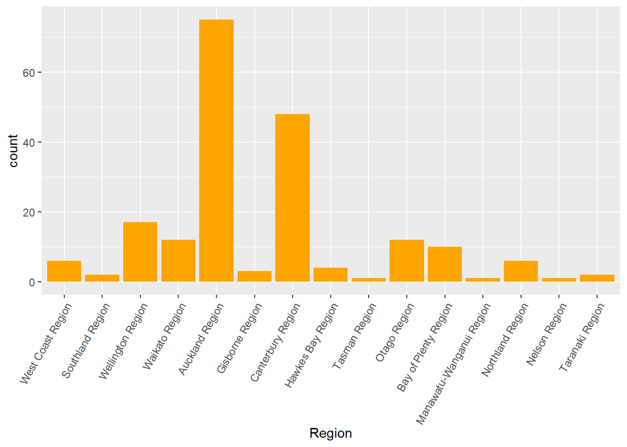

```r
demo_data <- data[,c("Year", "Region", "Gender", "Age", "Country", "New Zealand European", "Maori", "Samoan", "Cook Islands Maori", "Tongan", "Niuean", "Chinese", "Indian", "Other ethnicity", "Languages spoken")]
ggplot(demo_data, aes(Region)) +
geom_bar(fill="orange") + theme(axis.text.x = element_text(angle=60, hjust=1))
```

### 2.3.3 Gender

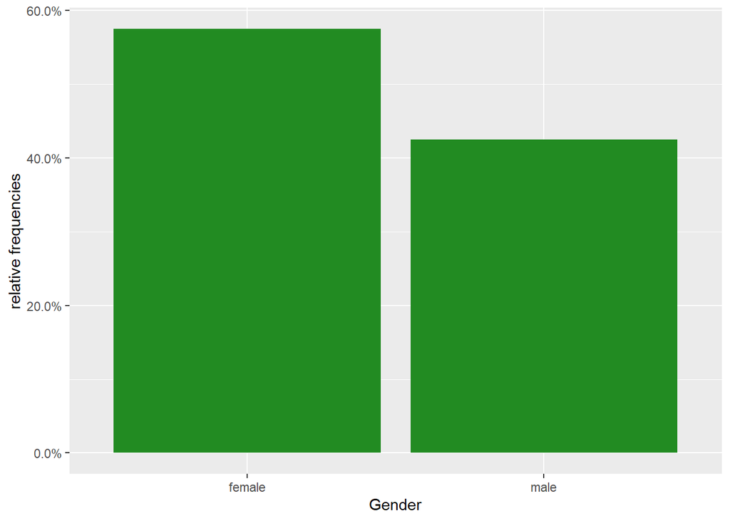

```r
ggplot(demo_data, aes(Gender)) +
  geom_bar(aes(y=(..count..)/sum(..count..)), fill="forest green") +
          scale_y_continuous(labels=scales::percent) +
  ylab("relative frequencies")
```

### 2.3.4 Age

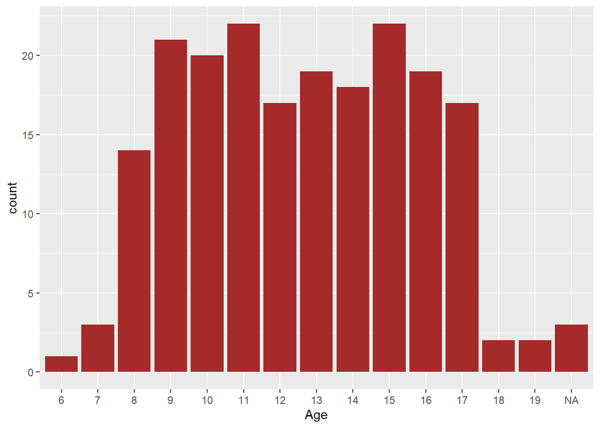

```r
ggplot(demo_data, aes(Age)) +
  geom_bar(fill="brown")
```

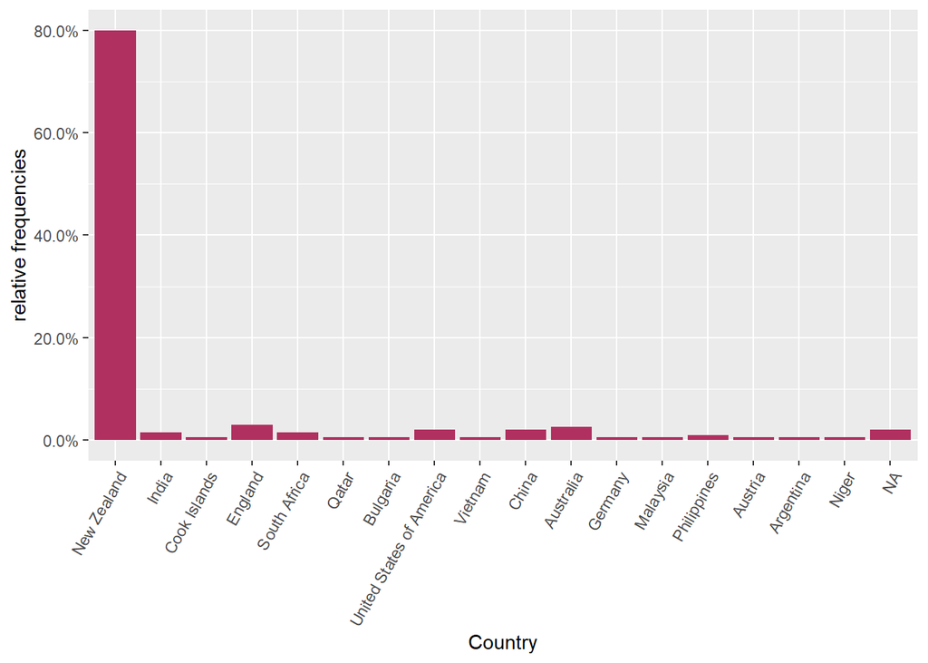

```r
ggplot(demo_data, aes(Country)) +
  geom_bar(aes(y=(..count..)/sum(..count..)), fill="maroon") +
  theme(axis.text.x = element_text(angle=60, hjust=1)) +
  scale_y_continuous(labels=scales::percent) +
  ylab("relative frequencies")
```

### 2.3.6 Number of Languages Spoken

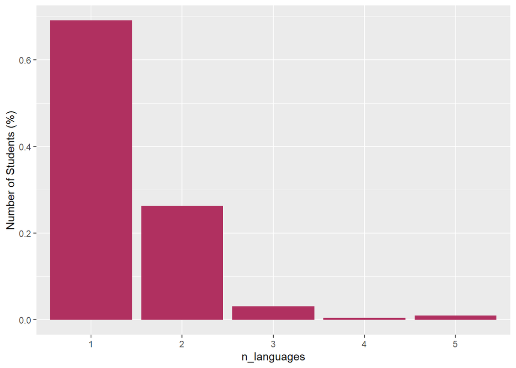

```r
lang_freq <- as.data.frame((table(demo_data$`Languages spoken`)))
colnames(lang_freq) <- c("n_languages", "freq")

ggplot(lang_freq, aes(n_languages)) +
  geom_bar(stat="identity", aes(y=freq/sum(freq)), fill="maroon") +
  ylab("Number of Students (%)")
```

```r
bg <- demo_data[,6:14]
bg$`Other ethnicity`[!is.na(bg$`Other ethnicity`)] <- "yes"
bg$`Other ethnicity`[is.na(bg$`Other ethnicity`)] <- "no"
res <- data.frame(colnames(bg), colSums(bg == 'no'), colSums(bg == "yes"), row.names=c(1:length(bg)))
colnames(res) <- c("ethnicity", "no", "yes")
attach(res)
res <-res[order(res$yes), ]
detach(res)
res
```

```
##              ethnicity  no yes
## 6               Niuean 199   1
## 4   Cook Islands Maori 198   2
## 5               Tongan 195   5
## 3               Samoan 192   8
## 7              Chinese 190  10
## 8               Indian 189  11
## 2                Maori 164  36
## 1 New Zealand European  52 148
## 9      Other ethnicity  NA  NA
```

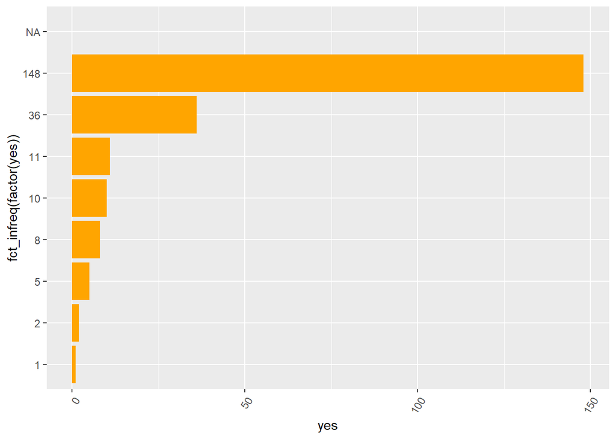

```r
# resLong <- melt(res, id=c("ethnicity"))
# ggplot(resLong) +
#   geom_bar(aes(x = ethnicity, y = value, fill = variable),
#            stat="identity", position = "dodge", width = 0.7) +
#   scale_fill_manual("Result\n", values = c("orange","forest green"),
#                     labels = c(" no", " yes")) +
#   labs(x="\nNumber",y="Result\n") +
#   coord_flip() +
#   theme_bw(base_size = 14) +
#   theme(axis.text.x = element_text(angle=60, hjust=1))
ggplot() + geom_col(data=res, aes(x=fct_infreq(factor(yes)), y=yes), fill="orange") + coord_flip() +
    theme(axis.text.x = element_text(angle=60, hjust=1))
```

```r
# head(demo_data[,6:14])
# #Using GGPLOT, plot the Base World Map
# mp <- NULL
# mapWorld <- borders("world", colour="gray50", fill="gray50") # create a layer of borders
# mp <- ggplot() +   mapWorld
#
# #Now Layer the cities on top
# mp <- mp+ geom_point(aes(x=demo_data, y=visit.y) ,color="blue", size=3)
# mp
```

```r
# ggplot(demo_data, aes(x=)) +
# geom_bar(stat="identity", position="fill") +
# geom_text(stat='count', aes(label=..count..), vjust=-1) +
# theme(axis.text.x = element_text(angle=60, hjust=1))
```

## 2.4 What is the most common method of travel to school?

```r
x = data$`Travel method to school`
y = table(x)
```

## 2.5 What are the most common favourite video games? You may want to use forcats::fct_lump() to group the least common games together.

```r
x = data$`Favourite video game`
y = table(x)
```

# 3 Research Questions

## 3.1 It is hypothesised that 90% of the population are right handed. Does your sample of data support this hypothesis? You may need to recode the data so that there are only two categories.

**Hypothesis:** $H_0$: 90% of the population are right-handed. $H_1$: 90% of the population are **not** right-handed. **Assumptions:** We assume this sample is randomly selected. We use a p-value of .05

**Test Statistic:** The data is a binomial distribution.

```r
x = data$Handedness
```

### 3.1.1 Is handedness independent of gender?

We want to test for homogeneity, so lets make a 2x2, two-way contingency table.

**Hypothesis:** $H_0$: There is no difference between the number of right and left-handed males and females. so the $e_{ij}=n_i\hat{p}_{ij} = y_i* \dfrac{y_j}{n}$ $H_1$: There is a difference between the number of right and left-handed males and females.

**Assumptions:** We assume this sample is randomly selected. We use a p-value of .05

```r
#Create a table with columns being left and right handed
#The rows are male and female
#Run chisquared test (End of lecture 07)
```

## 3.2 What proportion of students own a cell phone? Is this proportion constant across the different year groups? Perform a test to see if there is a statistically significant difference in cell phone ownership across year groups.

```r
prop_phones = length(which(data$`Own cell phone` == 'yes'))/length(data$`Own cell phone`)
```

```r
# Group by year groups and count the number of cell phones in each year group.
# prop_across_years = data[data$`Own cell phone`==TRUE]

# Create a table then run a chisquared test.
```

## 3.3 Restricting attention to students in years 7 to 12 who own a cell phone, is there an association between the tendency to check messages as soon as they wake up and feeling anxious when they’re without their phone. Do you get the same answer if you use a Monte Carlo p-value calculation? You may want to collapse some categories together, using forcats::fct_collapse().

**Hypothesis:** $H_0$: There is no association between students year 7-12 tendency to check messages as soon as they wake up, and feeling anxious when they’re without their phone. $H_1$: There is an association between students year 7-12 tendency to check messages as soon as they wake up, and feeling anxious when they’re without their phone. **Assumptions:** We assume this sample is randomly selected. We use a p-value of .05

```r
seven_to_twelve = dplyr::filter(data, Year >= 7, Year <= 12, `Own cell phone` == TRUE)

#group by those who check messages and those who don't
#subgroup by those who feel anxious and those who dont
#plot it to see if there is any visual suggestion
#run test on it
#run monte carlo pval
```

## 3.5 Are there any limitations of this data set?

# 4 conclusion

# 5 References

Wild, C. and Cunliffe, R. (2019). About - CensusAtSchool New Zealand. [online] CensusAtSchool New Zealand. Available at: https://new.censusatschool.org.nz/about/ [Accessed 26 Aug. 2019]. https://pages.github.sydney.edu.au/DATA2002/2019/m1_report.html https://www.earthdatascience.org/courses/earth-analytics/multispectral-remote-sensing-modis/add-variables-to-rmarkdown-report/ Yihui Xie_ J.J. Allaire_ Garrett Grolemund - R Markdown_ The Definitive Guide-CRC Press (2018) https://www.overleaf.com/learn/latex/Integrals,_sums_and_limits Labs and Lectures